# ggplot2

```r
library(ggplot2)
```

## Scatterplot

A scatterplot displays the values of two variables along two axes. It shows the relationship between them, eventually revealing a correlation.

Here the relationship between Sepal width and Sepal length of several plants is shown.

It illustrates the basic utilization of ggplot2 for scatterplots:

1 - provide a dataframe 2 - tell which variable to show on x and y axis 3 - add a geom_point() to show points.

```r
ggplot(iris, aes(x=Sepal.Length, y=Sepal.Width)) +
    geom_point()
```

[output not shown]

## Histogram

Histograms can be built with ggplot2 thanks to the geom_histogram() function. It requires only 1 numeric variable as input. This function automatically cut the variable in bins and count the number of data point per bin. Remember to try different bin size using the binwidth argument.

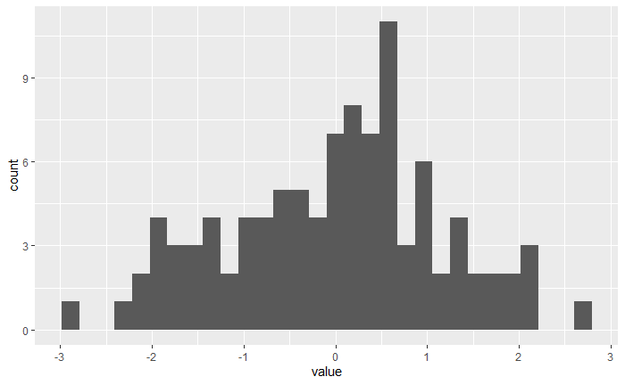

```r
# dataset:
data=data.frame(value=rnorm(100))

# basic histogram
ggplot(data, aes(x=value)) +
  geom_histogram()
```

## Barplot / Barchart

ggplot2 allows to build barplot thanks to the geom_bar() function. The examples below will guide you through the basics of this tool:

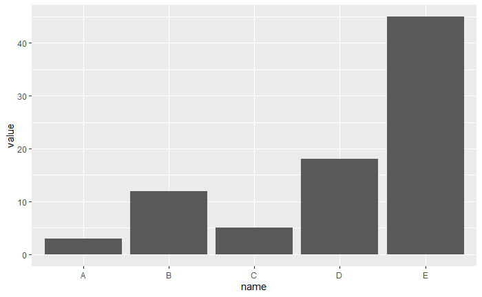

```r
# Create data
data <- data.frame(
  name=c("A","B","C","D","E") ,
  value=c(3,12,5,18,45)
  )

# Barplot
ggplot(data, aes(x=name, y=value)) +
  geom_bar(stat = "identity")
```

## Lineplot / Linechart

ggplot2 allows to draw line charts thanks to the geom_line() function. It expects as input a data frame with 2 numeric variables, one displayed on each axis. Start your journey with the most basic line chart.

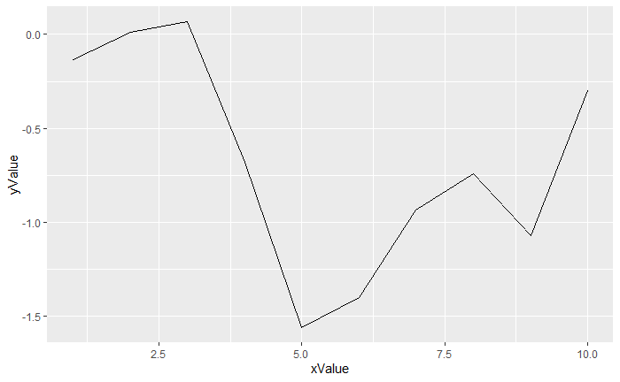

```r
# create data
xValue <- 1:10
yValue <- cumsum(rnorm(10))
data <- data.frame(xValue,yValue)

# Plot
ggplot(data, aes(x=xValue, y=yValue)) +
  geom_line()
```

## Boxplot

Boxplot are built thanks to the geom_boxplot() geom of ggplot2. See its basic usage on the first example below. Note that reordering groups is an important step to get a more insightful figure. Also, showing individual data points with jittering is a good way to avoid hiding the underlying distribution.

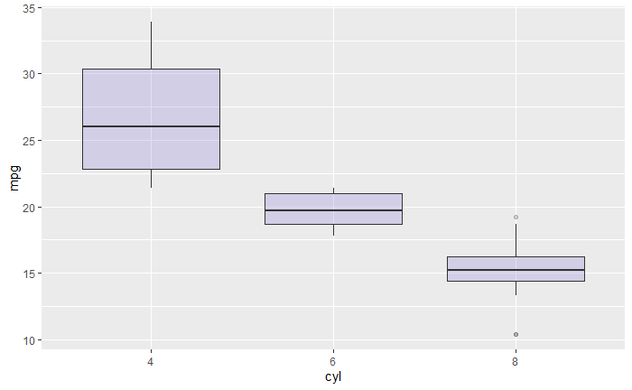

```r
# A really basic boxplot.
ggplot(mtcars, aes(x=as.factor(cyl), y=mpg)) +
    geom_boxplot(fill="slateblue", alpha=0.2) +
    xlab("cyl")
```

## Piechart

The pie() function is natively provided in R. It allows to build nice piechart in seconds. Here is an overview of its functioning:

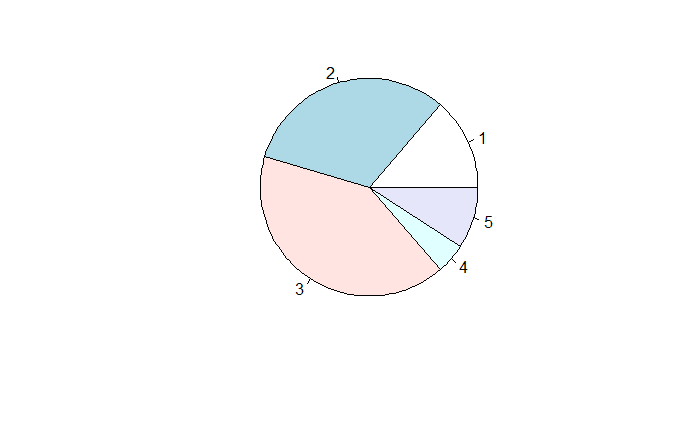

```r
Prop <- c(3,7,9,1,2)

# Make the default Pie Plot
pie(Prop)
```